# Welcome to Zhenkun's Homepage

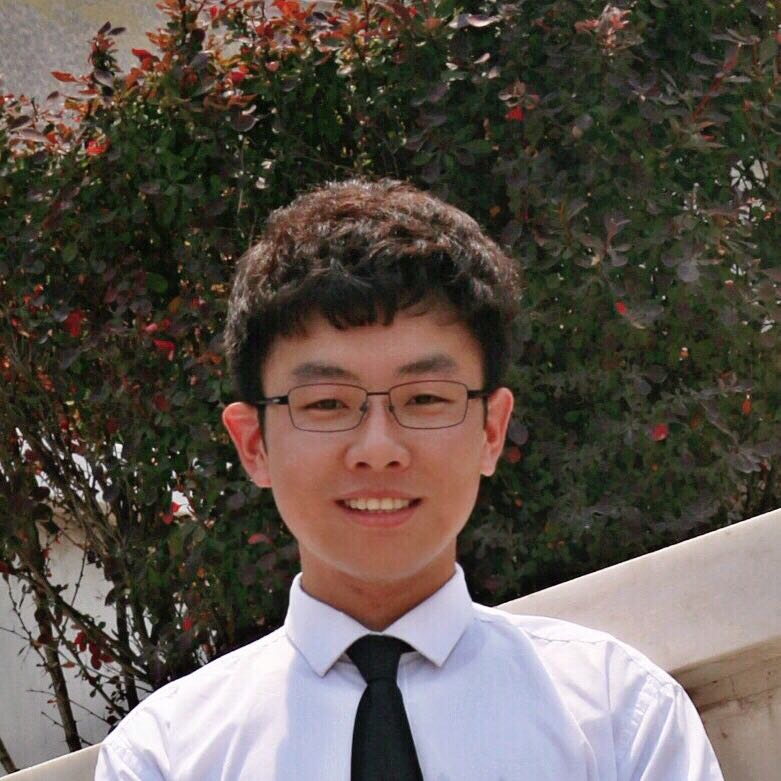

### ZHENKUN LI, MASTER OF ENGINEERING

Nationality: Chinese | Date of Birth: May 17, 1995

Tel.: +8618242081366 | Email: lizhenkunn@gmail.com

Institute: Beijing Smartbow Information Technology Co., Ltd.

### PERSONAL SUMMARY

- M. Eng. in Structural Engineering (Smart Materials and Structures);
- Interests: Structural health monitoring, system identification, damage detection, machine learning, computer vision.
- Strengths: math calculation, FE analysis, computer programming, time/frequency-domain signal analysis, data processing.

### EDUCATION

**09/2017-06/2020** Master of Engineering (M. Eng.), Structural Engineering, GPA: 3.76/4.0.

**Thesis topic:** Additional Virtual Mass Damage Identification Method Based on Narrow Band Frequency Responses (in Chinese, awarded with distinction).

**09/2013-06/2017** Bachelor of Engineering (B. Eng.), Civil Engineering, GPA: 86.03/100.

**Diploma thesis:** Architecture and structural design of HOTEL SWAN LAKE at Changdao (in Chinese).

### WORK EXPERIENCE

**04/2021-present**, Beijing Smartbow Information Technology Co., Ltd., Beijing, China. Structural Algorithm Engineer

**07/2020-03/2021**, TCDRI, Sinoma International Co., Ltd., Tianjin, China, Structural Engineer.

**09/2017-06/2019**, DUT, Dalian, China, Teaching Assistant (TA).

**09/2017-06/2019**, DUT, Dalian, China, Research Assistant (RA).

### PROFESSIONAL COMPETENCE & CERTIFICATES

- Mastered language: English(TOEFL 105; GRE 320+3.5), Chinese (mother tongue); Basic: Spanish.
- Machine learning(in Coursera: taught by Andrew Ng); Deep learning (book, written by Ian Goodfellow et al.)
- National Computer Rank Examination Certificate of Level 2 (C programming language).
- National Computer Rank Examination Certificate of Level 3 (Internet technology).
- National 1st Class Certified Structural Engineer.
- National Certificate of BIM Skill Proficiency Test Level 1.
- Main Software: Computing: MATLAB | Languages: Python, C, C++ | Numerical simulation: ANSYS, Abaqus, SAP2000 | Modeling: SOLIDWORKS, Revit | Text processing: MS Office, LaTeX, HTML5+CSS3 | Figures: OriginLab, Photoshop.

### SELECTED AWARDS & HONOURS

Jun. 2020 Excellent master thesis DUT

Jun. 2020 Eminent graduate in Liaoning Province Liaoning Province

Nov. 2019 Scholarship of Chinese Road and Bridge DUT

Oct. 2018 Eminent postgraduate student DUT

Oct. 2016 Scholarship from Shandong Province Government (only 1 among 508 students) Shandong Province

Dec. 2015 Second Prize in National Mathematic Modeling Competition National level

Nov. 2015 Third Prize in the National Advanced Innovated Competition National level

Jun. 2015 Second Prize in the 14th Challenge Cup Competition in Shandong Province Shandong Province

Nov. 2014 Scholarships from Principal of QUT (only 4 in 508 students) QUT

### COMMUNICATION & CONFERENCE

International conference: Experimental Vibration Analysis for Civil Engineering Structures (EVACES 2019) on Sep. 5-8, 2019, Nanjing, Jiangsu, China. Sponsor: Southeast University. [(pic.)](https://www.dropbox.com/s/jm88itu53kiz63s/EVACES2019.pdf?dl=0)

International conference: 7th World Conference on Structural Control and Monitoring (7WCSCM), on Jul. 22-25, 2018, Qingdao, Shandong, China. Sponsor: Harbin Institute of Technology & Qingdao University of Technology. [(pic.)](https://www.dropbox.com/s/t72ow2ftulvgb6t/7WCSCM.pdf?dl=0)

© Zhenkun Li. All rights reserved.

[Github](https://github.com/ZhenkunLi) [Research Gate](https://www.researchgate.net/profile/Zhenkun-Li-3) [LinkedIn](https://www.linkedin.com/in/zhenkun-li/) [ORCID](https://orcid.org/0000-0002-1444-6017) [GoogleScholar](https://scholar.google.com.hk/citations?hl=zh-CN&user=PrGJZLIAAAAJ)